# Question

Написать небольшую машинку классифицирующая наименования и ФИО.

К примеру, Иванов Иван Иванович – Это ФИО, ИП Иванов – наименование

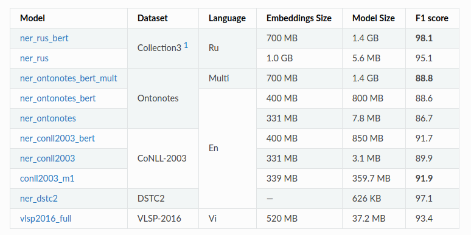

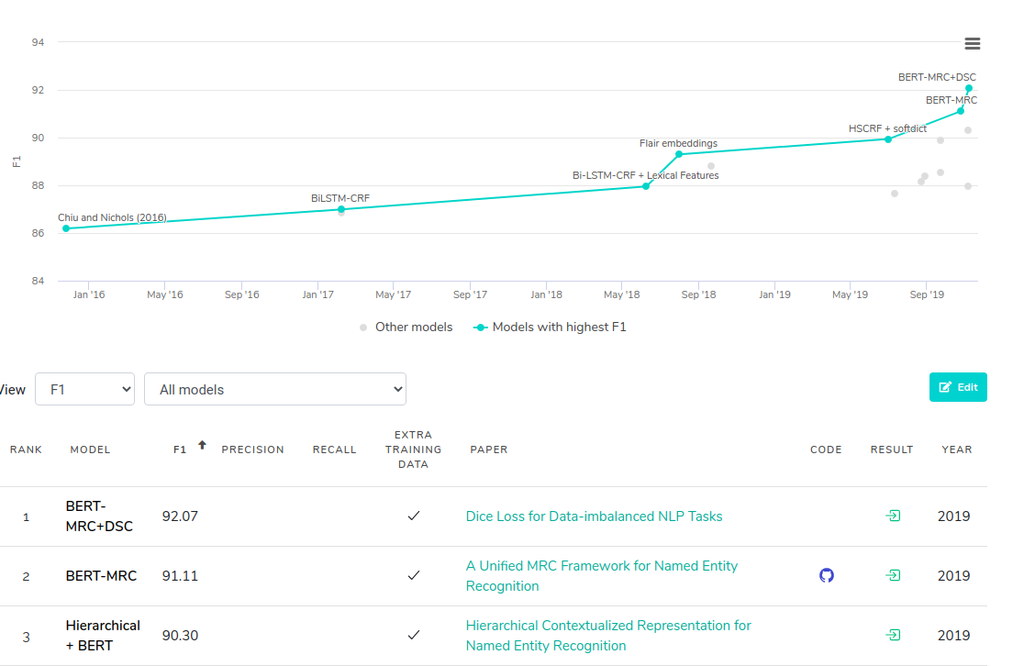

## TL

Первое, что приходит на ум, это заюзать Transfer Learning, взять обученную модельку от **DeepPavlov** и дообучить на нашем размеченном специфичном корпусе, посмотрим на перфоманс с предобученной моделькой

```python
from deeppavlov import configs, build_model
```

```python
ner_model = build_model(configs.ner.ner_rus_bert, download=True)
```

[output not shown]

[output not shown]

[output not shown]

[output not shown]

[output not shown]

[output cut: 155 more lines]

[output not shown]

[output not shown]

```python
ner_model(['Чемпионат мира по кёрлингу пройдёт в Антананариву'])
```

```
[[['Чемпионат', 'мира', 'по', 'кёрлингу', 'пройдёт', 'в', 'Антананариву']],
 [['O', 'O', 'O', 'O', 'O', 'O', 'B-LOC']]]
```

```python
ner_model(['Иванов Иван Иванович работает в организации ИП Иванов'])
```

```
[[['Иванов',
   'Иван',
   'Иванович',
   'работает',
   'в',
   'организации',
   'ИП',
   'Иванов']],
 [['B-PER', 'I-PER', 'I-PER', 'O', 'O', 'O', 'B-ORG', 'I-ORG']]]
```

```python
ner_model(['Halyk Bank, как ведущий финансовый институт Казахстана, сопереживает ситуации, в которой оказались наши соотечественники с введением режима чрезвычайного положения в стране.'])
```

```
[[['Halyk',
   'Bank',
   ',',
   'как',
   'ведущий',
   'финансовый',
   'институт',
   'Казахстана',
   ',',
   'сопереживает',
   'ситуации',
   ',',
   'в',
   'которой',
   'оказались',
   'наши',
   'соотечественники',
   'с',
   'введением',
   'режима',
   'чрезвычайного',
   'положения',
   'в',
   'стране',
   '.']],
 [['B-ORG',
   'I-ORG',
   'O',
   'O',
   'O',
   'O',
   'O',
   'B-LOC',
   'O',
   'O',
   'O',
   'O',
   'O',
   'O',
   'O',
   'O',
   'O',
   'O',
   'O',
   'O',
   'O',
   'O',
   'O',
   'O',
   'O']]]
```

## Виденье для кастомного решения и разметки датасета

В задачах выделения коротких последовательностей и сопоставление их с категориями есть пара нюансов:

- Когда у нас например дефолтная классификация, это значит что распределение факторизуется, то есть мы можем каждый объект-таргет отдельно обрабатывать, и на таргет влияет тока сам объект (его фичи). А в нашей постановке, каждый объект состоит из набора базовых элементов (символы, слова), в таком случае мы предсказываем не для каждого объекта, а для каждого его элемента плюс зависимость объектов друг от друга.
- Для таргетового датасета нужно будет сделать BIO-кодирование меток, чтобы знать где сущность началась когда кончилась, где началась другая. Есть еще более крутые но сложные методики, типа BMEWO (beginning, middle, ending, word, outside)

Архитектура для построения модельки:

- Получаем эмбеддинги слов или символов (любой фрэймворк юзаем семантический, типа w2v, glove, fasttext, bert, etc)
- Контекстуализация признаков
- Предсказываем вероятности классов, независимо, для каждого вектора признаков, получается число столбцов будет по количеству меток.
- Теперь согласовываем эти метки предсказанные, между собой (CRF, графическая вероятностная модель, условные случайные поля)

CRF - [Сonditional Random Field](https://towardsdatascience.com/conditional-random-fields-explained-e5b8256da776), граф, необходимый нам для предсказания распределение где каждый элемент зависит от предыдущего и следующего